# Python statsmodels

Doing great analyses, but with extra code

## Why statsmodels?

If you find yourself favoring Python, the choice is clear for things like typical machine learning tasks (Scikit-learn/sklearn). There are a few decisions to make for deep-learning (Keras or PyTorch), but both are pretty solid. What do you have for inferential stats? You could use *numpy*, but that is just a waste of time (why write methods for stuff when it exists elsewhere). You could use *scipy*, but you could get just as much from a decent calculator. You can absolutely miss me with, “yOu CaN uSe SkLeArN fOr EvErYtHiNg” nonsense – it works just fine for machine learning tasks, but is not built for inference at all. This is where *statsmodels* comes into play. It gives a whole ton of different stats functionality, in addition to working with right out of the box with pandas. It takes a specific view of the world (definitely coming from an econometric perspective), but it offers a great number of handy features that are scattered across several R packages.

### What It Won’t Do

It will do everything we learned in class (among other handy stuff – survival analysis, time series, MICE). It won’t do much for really common forms of dimension reduction tasks (factor analysis) or spatial work. Again, it is very clear this is built with the Econ folks in mind.

Want to run Python through RStudio? The `reticulate` package will do it!

## Using It

Of course, there are some packages to bring in:

```python
# We will be using both
import statsmodels.api as sm
import statsmodels.formula.api as smf

# Naturally, you need pandas
import pandas as pd

# But dask has most pandas functions, with more speed.
# Sometimes it works, but sometimes it doesn't
# import dask.dataframe as dd

# If you want easy design matrices, you need to bring in patsy:
from patsy import dmatrices
from patsy.contrasts import Treatment

# We should not need this:
import math

# But will definitely need this:
import numpy as np

# Rocking something based upon ggplot2
import seaborn as sns
import matplotlib.pyplot as plt

# Everybody enjoys a dark background:
plt.style.use("dark_background")
```

When we get to the modeling, you will need to pay attention to which package we are calling: `sm` works for everything, but `smf` is a bit limited.

Now let’s read in data that we have already seen:

```python
# If you use dd.read_csv, it will read fast, but slow indexing down.
# If you use pd.read_csv, it will read slow, but be fine afterwards.

crime_score = pd.read_csv("http://nd.edu/~sberry5/data/crimeScore.csv")

crime_score = crime_score[["SSL_SCORE", "WEAPONS_ARR_CNT", "SEX_CODE_CD",
  "COMMUNITY_AREA", "AGE_CURR"]]

# Note the filtering for COMMUNITY_AREA and AGE_CURR, definitely
# different than how R filters blank characters.

crime_score = crime_score[(crime_score.AGE_CURR != " ") &
                          (crime_score.SEX_CODE_CD != "X") &
                          (crime_score.COMMUNITY_AREA != " ")
]

crime_score["AGE_CURR"] = crime_score["AGE_CURR"].astype("category")

# The same idea as R's relevel:

crime_score["AGE_CURR"] = crime_score["AGE_CURR"].cat.reorder_categories(
    ["less than 20", "20-30", "30-40", "40-50", "50-60", "60-70", "70-80"]
)

crime_score = crime_score.dropna()
```

Let’s try an easy group by and summarize for gender and crime score:

```python
crime_score.groupby(by="SEX_CODE_CD")["SSL_SCORE"].mean()
```

```
SEX_CODE_CD
F    317.334728
M    323.568036
Name: SSL_SCORE, dtype: float64
```

Keep this in mind, because we will come back to it.

### Linear Regression

The statsmodels package makes use of *endogenous* and *exogenous* variable names. Those terms might not be familiar to you, so we can break it down:

Exogenous = Exogenous variables, and their values, live outside the model. The variables are directly imposed upon the model.

Endogenous = Endogenous variables, and their values, are determined by the model.

How does this map back to our models: $y = \beta_0 + \beta_1 X_1$

What part depends on the model – *y*

What values come from the world – *x*

Want any easy way to remember? The x variables (predictors/IVs) are e**x**ogenous! Since you’ve been using R, it might surprise you to know that statsmodels won’t take care of your factor variables for you. Instead, you need to create the dummy matrix through pandas and then subset your exogenous variables:

```python
exogX = pd.get_dummies(crime_score, columns=['SEX_CODE_CD'])[["WEAPONS_ARR_CNT",
  "SEX_CODE_CD_M"]]
```

More shocking than the lack of implicit treatment contrasts, is that statsmodels doesn’t include an intercept in the model by default…gtfo. There is an easy method for it; we can add the constant and then specify our endogenous variable:

```python
exogX = sm.add_constant(exogX)

endogY = (crime_score.SSL_SCORE)
```

Now, we can fit and produce the summary:

```python
results = sm.OLS(endogY, exogX).fit()

print(results.summary())
```

```
                            OLS Regression Results
==============================================================================
Dep. Variable:              SSL_SCORE   R-squared:                       0.026
Model:                            OLS   Adj. R-squared:                  0.025
Method:                 Least Squares   F-statistic:                     197.0
Date:                Sun, 15 Nov 2020   Prob (F-statistic):           3.57e-85
Time:                        08:14:13   Log-Likelihood:                -81059.
No. Observations:               15007   AIC:                         1.621e+05
Df Residuals:                   15004   BIC:                         1.621e+05
Df Model:                           2
Covariance Type:            nonrobust
===================================================================================
                      coef    std err          t      P>|t|      [0.025      0.975]
-----------------------------------------------------------------------------------
const             298.7063      2.630    113.571      0.000     293.551     303.862
WEAPONS_ARR_CNT    17.4939      0.888     19.691      0.000      15.752      19.235
SEX_CODE_CD_M       3.6316      2.498      1.454      0.146      -1.264       8.527
==============================================================================
Omnibus:                      295.184   Durbin-Watson:                   0.051
Prob(Omnibus):                  0.000   Jarque-Bera (JB):              616.743
Skew:                           0.062   Prob(JB):                    1.19e-134
Kurtosis:                       3.985   Cond. No.                         15.1
==============================================================================

Notes:
[1] Standard Errors assume that the covariance matrix of the errors is correctly specified.
```

You probably noticed that we needed to include the fit attribute to our OLS function.

We see familiar output, with some additional model diagnostics below the typical output. The Durbin-Watson test is telling us if our residuals are exhibiting autocorrelation (really more important for time series data). Still, it should be around 2 to indicate we don’t have residual problems.

We also see the Jarque-Bera test for normality – this tests the assumption of normally-distributed errors. The higher this value, the more likely it is that we have problems with this assumption. This all comes from our skewness (should be 0) and kurtosis values (should be 3).

The condition number (Cond. No.) provide an idea about multicollinearity – higher values (think in the 100’s), would indicate multicollinearity.

### Robust Regression

If you like the endogenous/exogenous way of doing things, that is awesome. Personally, I prefer a formula interface – it looks much more like the regression equation to me. We can use the formula api that we loaded in up front. Notice, though, that we aren’t using the `OLS` function, but the `ols` function. Let’s define our formula and then fit a series of models:

```python
formula = 'SSL_SCORE ~ WEAPONS_ARR_CNT + SEX_CODE_CD'

mod1 = smf.ols(formula=formula, data=crime_score)
fittedMod1 = mod1.fit()
print(fittedMod1.summary())
```

```
                            OLS Regression Results
==============================================================================
Dep. Variable:              SSL_SCORE   R-squared:                       0.026
Model:                            OLS   Adj. R-squared:                  0.025
Method:                 Least Squares   F-statistic:                     197.0
Date:                Sun, 15 Nov 2020   Prob (F-statistic):           3.57e-85
Time:                        08:14:13   Log-Likelihood:                -81059.
No. Observations:               15007   AIC:                         1.621e+05
Df Residuals:                   15004   BIC:                         1.621e+05
Df Model:                           2
Covariance Type:            nonrobust
====================================================================================
                       coef    std err          t      P>|t|      [0.025      0.975]
------------------------------------------------------------------------------------
Intercept          298.7063      2.630    113.571      0.000     293.551     303.862
SEX_CODE_CD[T.M]     3.6316      2.498      1.454      0.146      -1.264       8.527
WEAPONS_ARR_CNT     17.4939      0.888     19.691      0.000      15.752      19.235
==============================================================================
Omnibus:                      295.184   Durbin-Watson:                   0.051
Prob(Omnibus):                  0.000   Jarque-Bera (JB):              616.743
Skew:                           0.062   Prob(JB):                    1.19e-134
Kurtosis:                       3.985   Cond. No.                         15.1
==============================================================================

Notes:
[1] Standard Errors assume that the covariance matrix of the errors is correctly specified.
```

That is the same model we previously saw, so let’s add some robust standard errors to that model:

```python
fittedMod1 = mod1.fit(cov_type="HC1")
print(fittedMod1.summary())
```

```
                            OLS Regression Results
==============================================================================
Dep. Variable:              SSL_SCORE   R-squared:                       0.026
Model:                            OLS   Adj. R-squared:                  0.025
Method:                 Least Squares   F-statistic:                     217.2
Date:                Sun, 15 Nov 2020   Prob (F-statistic):           1.05e-93
Time:                        08:14:13   Log-Likelihood:                -81059.
No. Observations:               15007   AIC:                         1.621e+05
Df Residuals:                   15004   BIC:                         1.621e+05
Df Model:                           2
Covariance Type:                  HC1
====================================================================================
                       coef    std err          z      P>|z|      [0.025      0.975]
------------------------------------------------------------------------------------
Intercept          298.7063      2.487    120.124      0.000     293.833     303.580
SEX_CODE_CD[T.M]     3.6316      2.371      1.532      0.126      -1.015       8.279
WEAPONS_ARR_CNT     17.4939      0.848     20.627      0.000      15.832      19.156
==============================================================================
Omnibus:                      295.184   Durbin-Watson:                   0.051
Prob(Omnibus):                  0.000   Jarque-Bera (JB):              616.743
Skew:                           0.062   Prob(JB):                    1.19e-134
Kurtosis:                       3.985   Cond. No.                         15.1
==============================================================================

Notes:
[1] Standard Errors are heteroscedasticity robust (HC1)
```

Now we have improved standard error estimates. What about outliers, I’m not sure if we have any, but that won’t stop us from adjusting like we have in the past:

```python
mod2 = smf.rlm(formula=formula,
  data=crime_score,
  M=sm.robust.norms.TukeyBiweight())

fittedMod2 = mod2.fit(cov="H1")
print(fittedMod2.summary())
```

```
                    Robust linear Model Regression Results
==============================================================================
Dep. Variable:              SSL_SCORE   No. Observations:                15007
Model:                            RLM   Df Residuals:                    15004
Method:                          IRLS   Df Model:                            2
Norm:                   TukeyBiweight
Scale Est.:                       mad
Cov Type:                          H1
Date:                Sun, 15 Nov 2020
Time:                        08:14:13
No. Iterations:                    14
====================================================================================
                       coef    std err          z      P>|z|      [0.025      0.975]
------------------------------------------------------------------------------------
Intercept          304.4306      2.485    122.490      0.000     299.559     309.302
SEX_CODE_CD[T.M]    -0.1900      2.360     -0.081      0.936      -4.816       4.436
WEAPONS_ARR_CNT     15.4566      0.840     18.411      0.000      13.811      17.102
====================================================================================

If the model instance has been used for another fit with different fit parameters, then the fit options might not be the correct ones anymore .
```

Now we have a regression model that is corrected for faulty standard errors and outliers – nice.

### Mixed-effects

We can add a random effect for community area into our model with a mixed-effects model:

```python
md = smf.mixedlm("SSL_SCORE ~ WEAPONS_ARR_CNT * SEX_CODE_CD",
                 crime_score,
                 groups=crime_score["COMMUNITY_AREA"])

mdf = md.fit(method=["lbfgs"])
print(mdf.summary())
```

```
                            Mixed Linear Model Regression Results
=============================================================================================
Model:                          MixedLM             Dependent Variable:             SSL_SCORE
No. Observations:               15007               Method:                         REML
No. Groups:                     77                  Scale:                          2843.2273
Min. group size:                1                   Log-Likelihood:                 inf
Max. group size:                1224                Converged:                      Yes
Mean group size:                194.9
---------------------------------------------------------------------------------------------
                                  Coef.    Std.Err.     z    P>|z|     [0.025       0.975]
---------------------------------------------------------------------------------------------
Intercept                         -0.000 28537634.412 -0.000 1.000 -55932735.651 55932735.651
SEX_CODE_CD[T.M]                 -20.897        9.291 -2.249 0.025       -39.108       -2.686
WEAPONS_ARR_CNT                   -4.372        8.346 -0.524 0.600       -20.729       11.985
WEAPONS_ARR_CNT:SEX_CODE_CD[T.M]  22.040        8.392  2.626 0.009         5.592       38.489
Group Var                          0.000
=============================================================================================
```

Nothing too exciting with grouping variable…let’s get a bit more wild!

### Poisson Regression

We can try to model our weapons arrest count variable with a Poisson model:

```python
countFomula = "WEAPONS_ARR_CNT ~ AGE_CURR + SEX_CODE_CD"

modCount = smf.glm(formula=countFomula, data=crime_score,
  family=sm.families.Poisson()).fit()

print(modCount.summary())
```

```
                 Generalized Linear Model Regression Results
==============================================================================
Dep. Variable:        WEAPONS_ARR_CNT   No. Observations:                15007
Model:                            GLM   Df Residuals:                    14999
Model Family:                 Poisson   Df Model:                            7
Link Function:                    log   Scale:                          1.0000
Method:                          IRLS   Log-Likelihood:                -17075.
Date:                Sun, 15 Nov 2020   Deviance:                       2341.0
Time:                        08:14:14   Pearson chi2:                 2.93e+03
No. Iterations:                     4
Covariance Type:            nonrobust
=====================================================================================
                        coef    std err          z      P>|z|      [0.025      0.975]
-------------------------------------------------------------------------------------
Intercept             0.0458      0.049      0.935      0.350      -0.050       0.142
AGE_CURR[T.20-30]     0.0643      0.026      2.514      0.012       0.014       0.114
AGE_CURR[T.30-40]    -0.0067      0.028     -0.240      0.811      -0.061       0.048
AGE_CURR[T.40-50]    -0.0665      0.037     -1.796      0.073      -0.139       0.006
AGE_CURR[T.50-60]    -0.1093      0.051     -2.156      0.031      -0.209      -0.010
AGE_CURR[T.60-70]    -0.1373      0.099     -1.380      0.168      -0.332       0.058
AGE_CURR[T.70-80]    -0.0513      0.334     -0.153      0.878      -0.706       0.604
SEX_CODE_CD[T.M]      0.1232      0.045      2.739      0.006       0.035       0.211
=====================================================================================
```

Our coefficients here are in log units, so we can exponentiate them to make a little more sense of them. Doing this, though, can be a bit of a hassle. The *math* package has an `exp` function, but it really only likes to take straight numbers; the *numpy* version of `exp` is more functional for us. Let’s try it two ways:

A “pythonic” method:

```python
for i in range(len(modCount.params.values)):
    print(math.exp(modCount.params.values[i]))
```

```
1.046895907322981
1.066440119330684
0.9933434130217097
0.9356546993065653
0.896469283659491
0.8717219996711248
0.9500031503739875
1.1311598325930603
```

And a vectorized method:

```python
np.exp(modCount.params)
```

```
Intercept            1.046896
AGE_CURR[T.20-30]    1.066440
AGE_CURR[T.30-40]    0.993343
AGE_CURR[T.40-50]    0.935655
AGE_CURR[T.50-60]    0.896469
AGE_CURR[T.60-70]    0.871722
AGE_CURR[T.70-80]    0.950003
SEX_CODE_CD[T.M]     1.131160
dtype: float64
```

What if we want to fit a Bayesian random effect to this model. Naturally, it will be some work, but it isn’t too bad!

```python
random = {"a": '0 + C(COMMUNITY_AREA)'}

model = sm.PoissonBayesMixedGLM.from_formula(
               'WEAPONS_ARR_CNT ~ AGE_CURR + SEX_CODE_CD', random, crime_score)

result = model.fit_vb()

result.summary
```

```
<bound method BayesMixedGLMResults.summary of <statsmodels.genmod.bayes_mixed_glm.BayesMixedGLMResults object at 0x7fbbc6279940>>
```

Let’s plot those random effects to see how they shake out:

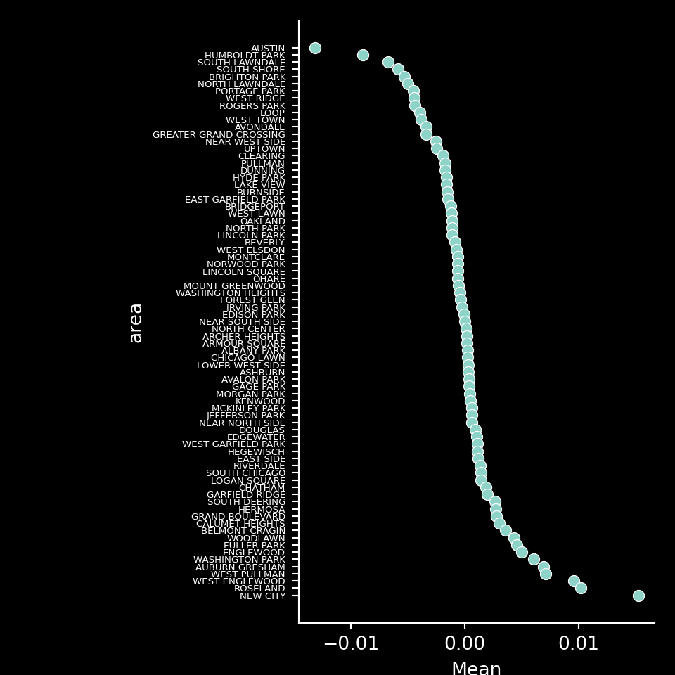

```python
reData = result.random_effects()

reData.index.name = 'area'
reData.reset_index(inplace=True)

reData.area = reData.replace(to_replace ='C.*\)|\[|\]', value = '', regex = True)

reData = reData.sort_values("Mean")

sns.relplot(x="Mean", y="area", data=reData).set_yticklabels(size=5)
plt.show()
```

### Bootstrapping

Finally, we can boostrap our original model.

```python
formula = 'SSL_SCORE ~ WEAPONS_ARR_CNT + SEX_CODE_CD'

def bootstrapping(data, formula):
  data = data.sample(data.__len__(), replace = True)
  mod1 = smf.ols(formula=formula, data=data)
  fittedMod1 = mod1.fit()
  return pd.DataFrame(fittedMod1.tvalues, columns = ["value"])

bootstrapping(crime_score, formula)
```

```
                       value
Intercept         118.730185
SEX_CODE_CD[T.M]    0.775268
WEAPONS_ARR_CNT    18.504349
```

```python
replicates = 10
results = []

for i in range(replicates):
  modRes = bootstrapping(crime_score, formula)
  results.append(modRes)

bootOut = pd.concat(results)
bootOut.index.name = 'term'
bootOut.reset_index(inplace=True)

bootOut.value[bootOut.term == "WEAPONS_ARR_CNT"]
```

```
2     18.742487
5     19.322853
8     20.409919
11    21.619033
14    19.383954
17    19.767317
20    18.728700
23    18.636027
26    19.772812
29    20.491642
Name: value, dtype: float64
```

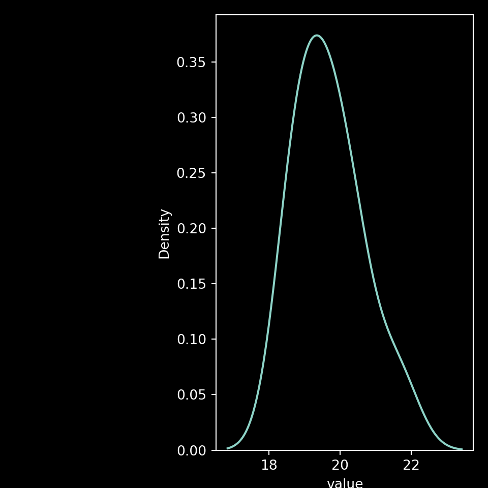

```python
sns.kdeplot(bootOut.value[bootOut.term == "WEAPONS_ARR_CNT"],
  palette="pastel")
plt.show()
```